# Описание проекта по теме "Численные методы".

Сервис по продаже автомобилей с пробегом «Не бит, не крашен» разрабатывает приложение для привлечения новых клиентов. В нём можно быстро узнать рыночную стоимость своего автомобиля. В вашем распоряжении исторические данные: технические характеристики, комплектации и цены автомобилей. Вам нужно построить модель для определения стоимости.

Заказчику важны:

- качество предсказания;
- скорость предсказания;
- время обучения.

**Целью проекта** является построение модели градиентного бустинга для предсказания стоимости подержанного автомобиля, основываясь на различных параметрах, характиризующих различные свойства описываемого автомобиля.

**Целевой метрикой** проекта является RMSE.

По условиям проекта необходимо самостоятельно освоить библиотеку LightGBM, в частности - её модуль LGBMRegressor, так как задача проекта является задачей регрессии, однако в рамках эксперимента сравним работу этой модели с моделью градиентного бустинга CatBoost, не зря же в проекте Яндекса учимся - отдадим дань учителю.

Работу над проектом будем вести в следующем порядке:

1. Импорт библиотек, считывание набора данных и его первиный анализ.
2. Предобработка данных.
3. Построение моделей, выбор оптимальной модели.

# Этап 1. Импорт библиотек, считывание набора данных и его первиный анализ.

Сначала импортируем необходимые библиотеки.

```python
import warnings
warnings.filterwarnings('ignore')
import pandas as pd
import numpy as np
from sklearn.utils import parallel_backend
from sklearn.model_selection import GridSearchCV
from sklearn.model_selection import train_test_split
from lightgbm import LGBMRegressor
from catboost import CatBoostRegressor
from sklearn.metrics import mean_squared_error as mse
from sklearn.metrics import make_scorer
import time
import matplotlib.pyplot as plt
import seaborn as sns
```

Считываем набор данных.

```python
df = pd.read_csv('autos.csv')
```

Для первичного анализа набора данных напишем функцию, принимающую на вход набор данных и выводящую о нём основную интересующую нас информацию: первые 10 строк, общую информацию о наборе данных, размер набора данных, количество дубликатов и пропусков, а также частота встречаемости уникальных значений каждого признака.

```python
def df_info(df):
    print('Первые 10 строк DF')
    display(df.head(10))
    print('Общая информация о DF')
    display(df.info())
    print('Размер df:', df.shape)
    print()
    print('Пропуски в df')
    display(df.isna().sum())
    print('Количество дубликатов в df:', df.duplicated().sum())
    print()
    for col in df.columns:
        print('*** Поле', col + ': уникальные значения ***')
        display(df[col].value_counts())
df_info(df)
```

```
Первые 10 строк DF
```

|  | DateCrawled | Price | VehicleType | RegistrationYear | Gearbox | Power | Model | Kilometer | RegistrationMonth | FuelType | Brand | NotRepaired | DateCreated | NumberOfPictures | PostalCode | LastSeen |
| --- | --- | --- | --- | --- | --- | --- | --- | --- | --- | --- | --- | --- | --- | --- | --- | --- |
| 0 | 2016-03-24 11:52:17 | 480 | NaN | 1993 | manual | 0 | golf | 150000 | 0 | petrol | volkswagen | NaN | 2016-03-24 00:00:00 | 0 | 70435 | 2016-04-07 03:16:57 |
| 1 | 2016-03-24 10:58:45 | 18300 | coupe | 2011 | manual | 190 | NaN | 125000 | 5 | gasoline | audi | yes | 2016-03-24 00:00:00 | 0 | 66954 | 2016-04-07 01:46:50 |
| 2 | 2016-03-14 12:52:21 | 9800 | suv | 2004 | auto | 163 | grand | 125000 | 8 | gasoline | jeep | NaN | 2016-03-14 00:00:00 | 0 | 90480 | 2016-04-05 12:47:46 |
| 3 | 2016-03-17 16:54:04 | 1500 | small | 2001 | manual | 75 | golf | 150000 | 6 | petrol | volkswagen | no | 2016-03-17 00:00:00 | 0 | 91074 | 2016-03-17 17:40:17 |
| 4 | 2016-03-31 17:25:20 | 3600 | small | 2008 | manual | 69 | fabia | 90000 | 7 | gasoline | skoda | no | 2016-03-31 00:00:00 | 0 | 60437 | 2016-04-06 10:17:21 |
| 5 | 2016-04-04 17:36:23 | 650 | sedan | 1995 | manual | 102 | 3er | 150000 | 10 | petrol | bmw | yes | 2016-04-04 00:00:00 | 0 | 33775 | 2016-04-06 19:17:07 |
| 6 | 2016-04-01 20:48:51 | 2200 | convertible | 2004 | manual | 109 | 2_reihe | 150000 | 8 | petrol | peugeot | no | 2016-04-01 00:00:00 | 0 | 67112 | 2016-04-05 18:18:39 |
| 7 | 2016-03-21 18:54:38 | 0 | sedan | 1980 | manual | 50 | other | 40000 | 7 | petrol | volkswagen | no | 2016-03-21 00:00:00 | 0 | 19348 | 2016-03-25 16:47:58 |
| 8 | 2016-04-04 23:42:13 | 14500 | bus | 2014 | manual | 125 | c_max | 30000 | 8 | petrol | ford | NaN | 2016-04-04 00:00:00 | 0 | 94505 | 2016-04-04 23:42:13 |
| 9 | 2016-03-17 10:53:50 | 999 | small | 1998 | manual | 101 | golf | 150000 | 0 | NaN | volkswagen | NaN | 2016-03-17 00:00:00 | 0 | 27472 | 2016-03-31 17:17:06 |

```
Общая информация о DF
<class 'pandas.core.frame.DataFrame'>
RangeIndex: 354369 entries, 0 to 354368
Data columns (total 16 columns):
 #   Column             Non-Null Count   Dtype
---  ------             --------------   -----
 0   DateCrawled        354369 non-null  object
 1   Price              354369 non-null  int64
 2   VehicleType        316879 non-null  object
 3   RegistrationYear   354369 non-null  int64
 4   Gearbox            334536 non-null  object
 5   Power              354369 non-null  int64
 6   Model              334664 non-null  object
 7   Kilometer          354369 non-null  int64
 8   RegistrationMonth  354369 non-null  int64
 9   FuelType           321474 non-null  object
 10  Brand              354369 non-null  object
 11  NotRepaired        283215 non-null  object
 12  DateCreated        354369 non-null  object
 13  NumberOfPictures   354369 non-null  int64
 14  PostalCode         354369 non-null  int64
 15  LastSeen           354369 non-null  object
dtypes: int64(7), object(9)
memory usage: 43.3+ MB
```

```
None
```

```
Размер df: (354369, 16)

Пропуски в df
```

```
DateCrawled              0
Price                    0
VehicleType          37490
RegistrationYear         0
Gearbox              19833
Power                    0
Model                19705
Kilometer                0
RegistrationMonth        0
FuelType             32895
Brand                    0
NotRepaired          71154
DateCreated              0
NumberOfPictures         0
PostalCode               0
LastSeen                 0
dtype: int64
```

```
Количество дубликатов в df: 4

*** Поле DateCrawled: уникальные значения ***
```

```
2016-03-24 14:49:47    7
2016-03-19 21:49:56    6
2016-03-26 22:57:31    6
2016-03-22 10:42:10    5
2016-03-16 13:47:44    5
                      ..
2016-03-05 22:40:37    1
2016-04-03 15:47:07    1
2016-03-18 18:52:30    1
2016-03-08 08:53:09    1
2016-03-08 12:41:38    1
Name: DateCrawled, Length: 271174, dtype: int64
```

```
*** Поле Price: уникальные значения ***
```

```
0        10772
500       5670
1500      5394
1000      4649
1200      4594
         ...
13440        1
1414         1
8069         1
10370        1
384          1
Name: Price, Length: 3731, dtype: int64
```

```
*** Поле VehicleType: уникальные значения ***
```

```
sedan          91457
small          79831
wagon          65166
bus            28775
convertible    20203
coupe          16163
suv            11996
other           3288
Name: VehicleType, dtype: int64
```

```
*** Поле RegistrationYear: уникальные значения ***
```

```
2000    24490
1999    22728
2005    22109
2001    20124
2006    19900
        ...
3200        1
1920        1
1919        1
1915        1
8455        1
Name: RegistrationYear, Length: 151, dtype: int64
```

```
*** Поле Gearbox: уникальные значения ***
```

```
manual    268251
auto       66285
Name: Gearbox, dtype: int64
```

```
*** Поле Power: уникальные значения ***
```

```
0        40225
75       24023
60       15897
150      14590
101      13298
         ...
16311        1
1360         1
1968         1
6226         1
6006         1
Name: Power, Length: 712, dtype: int64
```

```
*** Поле Model: уникальные значения ***
```

```
golf                  29232
other                 24421
3er                   19761
polo                  13066
corsa                 12570
                      ...
serie_2                   8
rangerover                4
serie_3                   4
range_rover_evoque        2
serie_1                   2
Name: Model, Length: 250, dtype: int64
```

```
*** Поле Kilometer: уникальные значения ***
```

```
150000    238209
125000     36454
100000     14882
90000      11567
80000      10047
70000       8593
60000       7444
5000        6397
50000       6232
40000       4911
30000       4436
20000       3975
10000       1222
Name: Kilometer, dtype: int64
```

```
*** Поле RegistrationMonth: уникальные значения ***
```

```
0     37352
3     34373
6     31508
4     29270
5     29153
7     27213
10    26099
12    24289
11    24186
9     23813
1     23219
8     22627
2     21267
Name: RegistrationMonth, dtype: int64
```

```
*** Поле FuelType: уникальные значения ***
```

```
petrol      216352
gasoline     98720
lpg           5310
cng            565
hybrid         233
other          204
electric        90
Name: FuelType, dtype: int64
```

```
*** Поле Brand: уникальные значения ***
```

```
volkswagen        77013
opel              39931
bmw               36914
mercedes_benz     32046
audi              29456
ford              25179
renault           17927
peugeot           10998
fiat               9643
seat               6907
mazda              5615
skoda              5500
smart              5246
citroen            5148
nissan             4941
toyota             4606
hyundai            3587
sonstige_autos     3374
volvo              3210
mini               3202
mitsubishi         3022
honda              2817
kia                2465
suzuki             2323
alfa_romeo         2314
chevrolet          1754
chrysler           1439
dacia               900
daihatsu            806
subaru              762
porsche             758
jeep                677
trabant             589
land_rover          545
daewoo              542
saab                526
jaguar              505
rover               486
lancia              471
lada                225
Name: Brand, dtype: int64
```

```
*** Поле NotRepaired: уникальные значения ***
```

```
no     247161
yes     36054
Name: NotRepaired, dtype: int64
```

```
*** Поле DateCreated: уникальные значения ***
```

```
2016-04-03 00:00:00    13719
2016-04-04 00:00:00    13317
2016-03-20 00:00:00    12918
2016-03-12 00:00:00    12840
2016-03-21 00:00:00    12691
                       ...
2014-03-10 00:00:00        1
2015-11-08 00:00:00        1
2015-06-18 00:00:00        1
2016-01-08 00:00:00        1
2015-03-20 00:00:00        1
Name: DateCreated, Length: 109, dtype: int64
```

```
*** Поле NumberOfPictures: уникальные значения ***
```

```
0    354369
Name: NumberOfPictures, dtype: int64
```

```
*** Поле PostalCode: уникальные значения ***
```

```
10115    819
65428    613
66333    343
44145    317
32257    317
        ...
6725       1
6922       1
85071      1
97528      1
63931      1
Name: PostalCode, Length: 8143, dtype: int64
```

```
*** Поле LastSeen: уникальные значения ***
```

```
2016-04-06 13:45:54    17
2016-04-06 04:15:59    16
2016-04-06 09:17:58    16
2016-04-06 12:15:45    16
2016-04-06 08:46:30    16
                       ..
2016-03-31 10:16:06     1
2016-03-17 20:18:17     1
2016-03-23 05:47:00     1
2016-04-05 12:29:56     1
2016-03-29 18:54:22     1
Name: LastSeen, Length: 179150, dtype: int64
```

Описание признаков в наборе данных:

- DateCrawled — дата скачивания анкеты из базы;
- VehicleType — тип автомобильного кузова;
- RegistrationYear — год регистрации автомобиля;
- Gearbox — тип коробки передач;
- Power — мощность (л. с.);
- Model — модель автомобиля;
- Kilometer — пробег (км);
- RegistrationMonth — месяц регистрации автомобиля;
- FuelType — тип топлива;
- Brand — марка автомобиля;
- NotRepaired — была машина в ремонте или нет;
- DateCreated — дата создания анкеты;
- NumberOfPictures — количество фотографий автомобиля;
- PostalCode — почтовый индекс владельца анкеты (пользователя);
- LastSeen — дата последней активности пользователя;
- Price - цена автомобиля (евро) (целевой признак).

# Вывод по этапу 1.

На данном этапе были импортированы необходимые библиотеки, а также считан и проанализирован первичный набор данных.

По итогу первичного анализа набора данных можно отметить следующие его особенности:

1. Набор данных содержит 16 признаков, в том числе признак Price, являющийся целевым.
2. Набор данных содержит 354 369 объектов.
3. В наборе данных содержатся пропуски:
- признак VehicleType - 37 490 пропусков;
- признак Gearbox - 19 833 пропуска;
- признак Model - 19 705 пропусков;
- признак FuelType - 32 895 пропусков;
- признак NotRepaired - 71 154 пропусков.

Пропуски могли быть обусловлены либо проблемами с хранилищем данных сервиса по продаже автомобилей, либо изначальным отсутствием этих сведений в объявлениях, так как платформа - агрегатор вторичных объявлений, где какие-то параметры могут быть не заполнены.

1. Набор данных содержит 4 дубликата: возможно, одно объявление было загружено несколько раз в связи с техническими неполадками сервиса при загрузке, когда пользователь видел сообщение о том, что объявление не было загружено, хотя на самом деле они загружались при каждой попытке.
2. Данные в наборе данных являются либо данными в формате int64, либо данными в формате object, хотя фактически у нас есть также поля и с датами. Чтобы с ними работать, их нужно будет перевести в формат datetime с помощью соответствующего метода Pandas.
3. Поле NumberOfPictures кажется аномальным и содержит только объекты с меткой 0. Потенциально этот признак не представляет ценности для моделирования, и его смело можно удалить из набора данных.

# Этап 2. Предобработка данных.

На данном этапе осуществим предобработку данных и подготовим их для моделирования.

В рамках этапа нам предстоит:

1. Избавиться от дубликатов.
2. Сгенерировать новые признаки.
3. Избавиться от пропусков.

## Этап 2.1. Удаление дубликатов.

Напомним, что в наборе данных имеются 4 дубликата. Их довольно просто удалить.

```python
df = df.drop_duplicates().reset_index(drop=True)
```

## Этап 2.2. Генерация новых признаков.

У нас есть несколько признаков, представляющих собой дату: это признаки DateCreated (дата создания объявления), DateCrawled (адата загрузки объявления из базы) и LastSeen (дата последнего просмотра объявления).

На самом деле, даты - ценный кладезь информации, из которого можно сделать множество разнообразных признаков.

Для начала извлечём из признака DateCreated год и месяц создания объявления.

Затем сделаем новый признак, который покажет, сколько лет прошло между годом создания объявления и годом регистрации автомобиля.

```python
df['YearCreated'] = pd.to_datetime(df['DateCreated']).dt.year
df['MonthCreated'] = pd.to_datetime(df['DateCreated']).dt.month
df['RegistrationDifferenceYear'] = df['YearCreated'] - df['RegistrationYear']
```

Далее создадим признак так называемой релевантности объявления, который будет показывать, насколько интересно данное объявление покупателю. Логика в следующем: если между датой создания и датой последнего просмотра прошло немного дней, то объявление, вероятно, было быстро найдено покупателем, и стороны совершили сделку. Если же объявление не смотрели уже давно, можно предположить, что объявление не представляет интереса для широких масс покупателей.

Чтобы посчитать количество дней между двумя датами, воспользуемся методом date_range, где начальной датой будет дата создания объявления, конечной датой - дата последнего просмотра, а интервалом будет день. Данный метод вернёт список дней между двумя датами. Чтобы узнать количество дней, посчитаем длину списка функцией len. Эту длину функция будет возвращать для каждого автомобиля.

Чтобы посчиталось быстрее, запараллелим вычисления, чтобы работали все ядра.

```python
def Relevance(row):
    DateCreated = pd.to_datetime(row['DateCreated'])
    LastSeen = pd.to_datetime(row['LastSeen'])

    return len(pd.date_range(start=DateCreated, end=LastSeen, freq='D'))
with parallel_backend('threading'):
    df['Relevance'] = df.apply(Relevance, axis=1)
```

Проверим, что у нас получилось.

```python
df.head()
```

|  | DateCrawled | Price | VehicleType | RegistrationYear | Gearbox | Power | Model | Kilometer | RegistrationMonth | FuelType | Brand | NotRepaired | DateCreated | NumberOfPictures | PostalCode | LastSeen | YearCreated | MonthCreated | RegistrationDifferenceYear | Relevance |
| --- | --- | --- | --- | --- | --- | --- | --- | --- | --- | --- | --- | --- | --- | --- | --- | --- | --- | --- | --- | --- |
| 0 | 2016-03-24 11:52:17 | 480 | NaN | 1993 | manual | 0 | golf | 150000 | 0 | petrol | volkswagen | NaN | 2016-03-24 00:00:00 | 0 | 70435 | 2016-04-07 03:16:57 | 2016 | 3 | 23 | 15 |
| 1 | 2016-03-24 10:58:45 | 18300 | coupe | 2011 | manual | 190 | NaN | 125000 | 5 | gasoline | audi | yes | 2016-03-24 00:00:00 | 0 | 66954 | 2016-04-07 01:46:50 | 2016 | 3 | 5 | 15 |
| 2 | 2016-03-14 12:52:21 | 9800 | suv | 2004 | auto | 163 | grand | 125000 | 8 | gasoline | jeep | NaN | 2016-03-14 00:00:00 | 0 | 90480 | 2016-04-05 12:47:46 | 2016 | 3 | 12 | 23 |
| 3 | 2016-03-17 16:54:04 | 1500 | small | 2001 | manual | 75 | golf | 150000 | 6 | petrol | volkswagen | no | 2016-03-17 00:00:00 | 0 | 91074 | 2016-03-17 17:40:17 | 2016 | 3 | 15 | 1 |
| 4 | 2016-03-31 17:25:20 | 3600 | small | 2008 | manual | 69 | fabia | 90000 | 7 | gasoline | skoda | no | 2016-03-31 00:00:00 | 0 | 60437 | 2016-04-06 10:17:21 | 2016 | 3 | 8 | 7 |

Видим, что мы сделали в точности то, что и планировали.

Теперь поработаем с признаком Kilometer, который описывает пробег автомобиля. Для покупателя автомобиля важен пробег: чем он выше, тем ниже будет стоимость автомобиля, так как по мере увеличения пробега автомобиль изнашивается.

Посмотрим на размах признака в наборе данных.

```python
print('Максимальный пробег:', df['Kilometer'].max(), 'километров')
print('Минимальный пробег:', df['Kilometer'].min(), 'километров')
```

```
Максимальный пробег: 150000 километров
Минимальный пробег: 5000 километров
```

С учётом этой информации категоризируем этот признак.

Напишем функцию, которая в зависимости от пробега будет присваивать автомобилю ту или иную категорию:

Функция будет принимать на вход значение признака Kilometer и возвращать соответствующую категорию.

```python
def Mileage(Kilometer):
    if Kilometer <= 7500:
        return 'low'
    elif 7500 < Kilometer <= 12500:
        return 'mean'
    return 'high'
```

Функция написана. Проверим её.

```python
print(Mileage(4499))
print(Mileage(8976))
print(Mileage(12500))
print(Mileage(13000))
```

```
low
mean
mean
high
```

Функция работает кооректно. Применим её к набору данных.

```python
df['Mileage'] = df['Kilometer'].apply(Mileage)
```

## Этап 2.3. Работа с пропущенными значениями.

Так как пропуски могут иметь естественную природу, их в целом можно оставить в том виде, в котором они есть. Однако чтобы модель определяла их как категорию пропущенных значений, преобразуем тип данных признаков, где есть пропуски, из object в str. Разница в том, что при типе данных object пропущенные значения всё так же будут пропущенными и выглядеть как NaN, а при преобразовании в str пропуски сформируют отдельную категорию nan, которая будет храниться в формате str.

Однако в целом можно было бы поизвращаться и сделать замену со словарём, сформированных их разных признаков. Например, пропуски в коробке передач можно было бы определить как наиболее часто встречающийся тип коробки передач в автомобилях определённой марки и определённого года выпуска. В такой конструкции доступ к значениям словаря можно было бы получить по мультиключу в форме кортежа, вроде (1994, 'volvo').

```python
df[['VehicleType', 'Gearbox', 'FuelType', 'Model', 'NotRepaired']] \
= df[['VehicleType', 'Gearbox', 'FuelType', 'Model', 'NotRepaired']].astype('str')
```

Пропуски обработаны.

Теперь, когда предобработка почти завершена, удалим признаки, которые не являются полезными с точки зрения предсказания стоимости.

В их числе: все даты (на их основе мы уже сделали новые признаки), а также почтовый код клиента.

```python
df.drop(['DateCrawled', 'DateCreated', 'LastSeen', 'PostalCode', 'NumberOfPictures'], axis=1, inplace=True)
```

Посмотрим на финальный набор данных.

```python
df.head()
```

|  | Price | VehicleType | RegistrationYear | Gearbox | Power | Model | Kilometer | RegistrationMonth | FuelType | Brand | NotRepaired | YearCreated | MonthCreated | RegistrationDifferenceYear | Relevance | Mileage |
| --- | --- | --- | --- | --- | --- | --- | --- | --- | --- | --- | --- | --- | --- | --- | --- | --- |
| 0 | 480 | nan | 1993 | manual | 0 | golf | 150000 | 0 | petrol | volkswagen | nan | 2016 | 3 | 23 | 15 | high |
| 1 | 18300 | coupe | 2011 | manual | 190 | nan | 125000 | 5 | gasoline | audi | yes | 2016 | 3 | 5 | 15 | high |
| 2 | 9800 | suv | 2004 | auto | 163 | grand | 125000 | 8 | gasoline | jeep | nan | 2016 | 3 | 12 | 23 | high |
| 3 | 1500 | small | 2001 | manual | 75 | golf | 150000 | 6 | petrol | volkswagen | no | 2016 | 3 | 15 | 1 | high |
| 4 | 3600 | small | 2008 | manual | 69 | fabia | 90000 | 7 | gasoline | skoda | no | 2016 | 3 | 8 | 7 | high |

Выглядит красиво.

# Выводы по этапу 2.

На данном этапе мы осуществили предобработку данных по следующим направлениям:

1. Избавиться от дубликатов.
2. Сгенерировать новые признаки.
3. Избавиться от пропусков.

Мы успешно избавились от дубоикатов, на основе признаков даты и пробега сгенерировали новые, потенциально полезные признаки, а также избавились от пропусков, сведя их к новой категории nan.

Также мы удалили признаки с датой, на основе которых были сгенерированы новые признаки, а также избавились от аномального признака NumberOfPictures, единственным уникальным значением которого был 0.

# Этап 3. Моделирование.

На данном этапе опробуем модели градиентного бустинга LightGBM и CatBoost. Обе модели умеют работать с категориальными значениями, и это очень кстати, так как у нас они есть.

## Этап 3.1. CatBoost.

Начнём с CatBoost. Кис-кис.

Сделаем копию набора данных, чтобы изменять его по своему усмотрению без потери исходных данных.

```python
df_for_cat_busts = df.copy()
```

Разделим набор данных на признаки и таргет. Напомним, что целевой признак - признак Price.

```python
features_cat = df_for_cat_busts.drop('Price', axis=1)
target_cat = df_for_cat_busts['Price']
```

Делим набор данных на тренировочную и тестовую выборки. Тест отщипнём в размере 20% от исходных данных.

```python
features_cat_train, features_cat_test, target_cat_train, target_cat_test = train_test_split(features_cat, target_cat,
                                                                                           random_state=42,
                                                                                            test_size = 0.20)
```

Для корректной работы алгоритма CatBoost необходимо указать ему на категориальные признаки. Для этого сформируем соответствующий списко.

```python
cat_features=['VehicleType', 'Gearbox', 'Model', 'FuelType', 'Brand', 'NotRepaired', 'Mileage']
```

Создаём экземпляр модели. Так как CatBoost умный, несмотря на то, что у него лапки, он довольно хорошо тюнит сам себя. Поэтому не будем его тюнить руками, чтобы не мешать ему делать свою работу, и будем использовать его из коробки. Единственный параметр, который нужно указать для достижения корректных результатов - функция потерь. В нашей задаче это RMSE, т.е. корень из среднеквадратической ошибки предсказаний.

```python
model = CatBoostRegressor(loss_function='RMSE')
```

Инициируем обучение модели.

Чтобы понять, сколько времени понадобится, используем библиотеку time и её модуль time, который фиксирует время в момент обращения к этому модулю.

Чтобы рассчитать время обучения модели, зафиксируем время до начала обучения модели в переменной start и время после окончания её обучения в переменной end. Разница между end и start - это и есть искомое нами время обучения модели. Эта разница будет показана в секундах.

Также при обучении модели передадим параметру plot значение True. Это построит нам красивый виджет, показывающий, как изменяется RMSE по мере увеличения числа итераций градиентного спуска.

```python
start = time.time()
model.fit(features_cat_train, target_cat_train, cat_features=cat_features, verbose=50, plot=True)
end = time.time()
learn_time = end - start
print('Время обучения модели:', learn_time)
```

```
Learning rate set to 0.106648
0:	learn: 4208.9787748	total: 277ms	remaining: 4m 37s
50:	learn: 1967.7265346	total: 10.2s	remaining: 3m 9s
100:	learn: 1866.2779619	total: 20.3s	remaining: 3m
150:	learn: 1816.6300624	total: 30.6s	remaining: 2m 52s
200:	learn: 1784.7645935	total: 41.2s	remaining: 2m 43s
250:	learn: 1762.5829613	total: 50.7s	remaining: 2m 31s
300:	learn: 1746.0059324	total: 1m	remaining: 2m 21s
350:	learn: 1730.4474218	total: 1m 10s	remaining: 2m 10s
400:	learn: 1719.7940848	total: 1m 20s	remaining: 2m
450:	learn: 1709.9027062	total: 1m 30s	remaining: 1m 50s
500:	learn: 1701.3982739	total: 1m 40s	remaining: 1m 39s
550:	learn: 1692.2723950	total: 1m 50s	remaining: 1m 29s
600:	learn: 1684.8365505	total: 2m	remaining: 1m 20s
650:	learn: 1676.4006031	total: 2m 11s	remaining: 1m 10s
700:	learn: 1670.8949876	total: 2m 21s	remaining: 1m
750:	learn: 1665.3746492	total: 2m 32s	remaining: 50.5s
800:	learn: 1659.1776090	total: 2m 42s	remaining: 40.3s
850:	learn: 1653.2551391	total: 2m 52s	remaining: 30.3s
900:	learn: 1648.1870181	total: 3m 3s	remaining: 20.1s
950:	learn: 1642.7810204	total: 3m 13s	remaining: 9.98s
999:	learn: 1638.0438655	total: 3m 23s	remaining: 0us
Время обучения модели: 205.72733354568481
```

Наша модель обучилась за 205.73 секунды, при этом обеспечив RMSE на уровне 1638.04 евро. Плохо это или нет? Непонятно. Узнаем чуть дальше.

```python
start = time.time()
pred = model.predict(features_cat_test)
end = time.time()
predict_time = end - start
```

С помощью обученной модели предскажем цену на автомобили из тестовой выборки.

```python
print('RMSE на отложенной выборке: {:.6f} евро, время обучения модели: {:.2f} секунд, время построение прогноза: {:.2f}\
 секунд, стандартная ошибка отложенного таргета: {:.6f} евро'.\
      format(mse(target_cat_test, pred, squared=False), learn_time, predict_time, target_cat_test.std()))
```

```
RMSE на отложенной выборке: 1704.009096 евро, время обучения модели: 205.73 секунд, время построение прогноза: 0.36 секунд, стандартная ошибка отложенного таргета: 4529.917661 евро
```

Видим, что на тестовой выборке модель в среднем ошибается на 1704.01 евро, при этом на обучение модели ушло 205.73 секунды. Для прогнозирования цен на автомобили из тестовой выборки модели понадобилось 0.36 секунд.

Чтобы понять, насколько хорошее значение RMSE, посмотрим на стандартное отклонение индивидуальных значений таргета от среднего значения. В нашем случае в тестовом наборе данных индивидуальные значения цен на автомобили отклоняются от среднего значения в среднем на 4529.92 евро.

Ошибка нашей модели в 2.66 раза меньше стандартного отклонения таргета, что даёт основания полагать, что наша модель довольно хорошо предсказывает цену на автомобили.

Посмотрим, какие признаки модель посчитала наиболее и наименее значимыми.

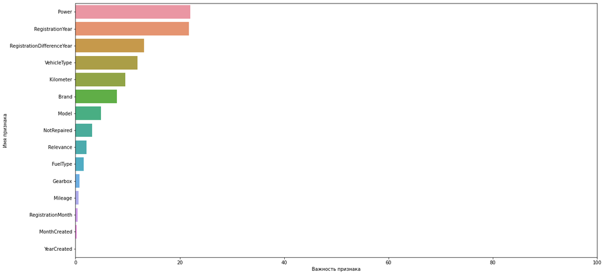

```python
feat_imp = pd.DataFrame({'FeatureName' : features_cat_test.columns, 'FeatureImportance' : model.feature_importances_})
feat_imp.sort_values('FeatureImportance', ascending=False, inplace=True)
fig, ax = plt.subplots(figsize = (20, 10))
ax = sns.barplot(ax = ax, data = feat_imp, y = 'FeatureName', x = 'FeatureImportance');
plt.xlabel('Важность признака')
plt.ylabel('Имя признака')
plt.xlim(0, 100);
```

Посмотрим на качество предсказания без 3 последних признаков.

```python
cat_features=['VehicleType', 'Gearbox', 'Model', 'FuelType', 'Brand', 'NotRepaired', 'Mileage']
start = time.time()
model.fit(features_cat_train[list(feat_imp['FeatureName'])[:-3]], target_cat_train,
          cat_features=cat_features, verbose=50, plot=True)
end = time.time()
learn_time = end - start
print('Время обучения модели:', learn_time)
```

```
Learning rate set to 0.106648
0:	learn: 4212.7756452	total: 198ms	remaining: 3m 17s
50:	learn: 1972.0810987	total: 7.97s	remaining: 2m 28s
100:	learn: 1870.4983010	total: 15.4s	remaining: 2m 17s
150:	learn: 1818.4338474	total: 23s	remaining: 2m 9s
200:	learn: 1791.1188196	total: 30.5s	remaining: 2m 1s
250:	learn: 1770.4308261	total: 37.6s	remaining: 1m 52s
300:	learn: 1751.8761306	total: 45s	remaining: 1m 44s
350:	learn: 1738.5334411	total: 52.6s	remaining: 1m 37s
400:	learn: 1726.8878915	total: 1m	remaining: 1m 29s
450:	learn: 1716.7063871	total: 1m 8s	remaining: 1m 22s
500:	learn: 1708.7242615	total: 1m 16s	remaining: 1m 16s
550:	learn: 1702.1520749	total: 1m 26s	remaining: 1m 10s
600:	learn: 1696.4761272	total: 1m 35s	remaining: 1m 3s
650:	learn: 1690.7757115	total: 1m 44s	remaining: 55.9s
700:	learn: 1682.3092887	total: 1m 53s	remaining: 48.3s
750:	learn: 1676.4135717	total: 2m 2s	remaining: 40.6s
800:	learn: 1670.4919705	total: 2m 11s	remaining: 32.7s
850:	learn: 1665.2604311	total: 2m 20s	remaining: 24.7s
900:	learn: 1659.1987449	total: 2m 29s	remaining: 16.5s
950:	learn: 1654.0775943	total: 2m 39s	remaining: 8.21s
999:	learn: 1649.7341892	total: 2m 48s	remaining: 0us
Время обучения модели: 170.4482023715973
```

```python
start = time.time()
pred = model.predict(features_cat_test[list(feat_imp['FeatureName'])[:-3]])
end = time.time()
predict_time = end - start
print('RMSE на отложенной выборке: {:.6f} евро, время обучения модели: {:.2f} секунд, время построение прогноза: {:.2f}\
 секунд, стандартная ошибка отложенного таргета: {:.6f} евро'.\
      format(mse(target_cat_test, pred, squared=False), learn_time, predict_time, target_cat_test.std()))
```

```
RMSE на отложенной выборке: 1712.602337 евро, время обучения модели: 170.45 секунд, время построение прогноза: 0.34 секунд, стандартная ошибка отложенного таргета: 4529.917661 евро
```

Модель стала хуже предсказывать цену на автомобиль всего лишь на 8 евро. Разбежка небольшая, поэтому в удалении признаков большого смысла нет.

Заключим, что CatBoost из коробки предсказывает цену на автомобиль с ошибкой в 1704.01 евро. При этом CatBoost потребовалась 205.73 секунды для обучения и 0.36 секунд для построения прогноза.

Посмотрим, как с этой задачей справится LightGBM.

## Этап 3.2. LightGBM.

Как и в прошлый раз, сделаем копию исходного набора данных, чтобы ничего в нём не менять.

```python
df_for_lgbm = df.copy()
```

Чтобы передать в LightGBM категориальные признаки, их можно либо преобразовать с численные с помощью Encoder, либо преобразовать их из типа object в тип category.

Численное преобразование немного снижает качество работы модели, поэтому преобразуем object в category.

```python
df_for_lgbm[cat_features] = df_for_lgbm[cat_features].astype('category')
```

```python
df_for_lgbm.head()
```

|  | Price | VehicleType | RegistrationYear | Gearbox | Power | Model | Kilometer | RegistrationMonth | FuelType | Brand | NotRepaired | YearCreated | MonthCreated | RegistrationDifferenceYear | Relevance | Mileage |
| --- | --- | --- | --- | --- | --- | --- | --- | --- | --- | --- | --- | --- | --- | --- | --- | --- |
| 0 | 480 | nan | 1993 | manual | 0 | golf | 150000 | 0 | petrol | volkswagen | nan | 2016 | 3 | 23 | 15 | high |
| 1 | 18300 | coupe | 2011 | manual | 190 | nan | 125000 | 5 | gasoline | audi | yes | 2016 | 3 | 5 | 15 | high |
| 2 | 9800 | suv | 2004 | auto | 163 | grand | 125000 | 8 | gasoline | jeep | nan | 2016 | 3 | 12 | 23 | high |
| 3 | 1500 | small | 2001 | manual | 75 | golf | 150000 | 6 | petrol | volkswagen | no | 2016 | 3 | 15 | 1 | high |
| 4 | 3600 | small | 2008 | manual | 69 | fabia | 90000 | 7 | gasoline | skoda | no | 2016 | 3 | 8 | 7 | high |

Далее разделяем набор данных на признаки и таргет и делим их на тренировочную и тестовую выборки. Размер тестовой выборки такой же - 20% от исходного набора данных.

```python
features_lgbm = df_for_lgbm.drop('Price', axis=1)
target_lgbm = df_for_lgbm['Price']
```

```python
features_lgbm_train, features_lgbm_test, target_lgbm_train, target_lgbm_test = train_test_split(features_lgbm, target_lgbm,
                                                                                           random_state=42,
                                                                                            test_size = 0.20)
```

Создаём экземпляр класса модели. В отличие от CatBoost, LightGBM нужно тюнить. Подбирать оптимальные параметры будем с помощью GridSearchCV, оптимизировать будем параметры learning_rate (скорость обучения) и num_leaves (количество листьев на дереве). Максимальная глубина дерева по умолчанию установлена на уровне -1, что значит, что она будет подбираться автоматически.

Постоянными параметрами установим n_estimators (количество деревьев) на уровне 800, colsample_bytree (доля признаков, участвующих в обучении каждого дерева) в размере 0.70 от исходного количества, subsample (доля объектов, участвующих в обучении каждого дерева) в размере 0.70 от исходного размера. Последние 2 параметра реализуют концепцию бутстрапирования, что, во-первых, помогает быстрее обучать модели, во-вторых, помогает избежать переобучения. При этом как данные, так и признаки могут участвовать в обучении более 1 раза, т.е. мы одновременно реализуем концепцию бутстрапирования и сэмплирования.

```python
model = LGBMRegressor(n_estimators=800, colsample_bytree=0.7, subsample=0.7)
```

Так как целевой метрикой модели является RMSE, а GridSearchCV по умолчанию максимизирует метрики, нужно сделать так, чтобы GridSearchCV не считал хорошей тенденцией увеличение метрики. За это отвечает параметр greater_is_better, ему нужно передать значение False. Также передадим параметру squared значение Fasle, чтобы считалось не MSE, а RMSE.

При обучении модели также будем использовать RMSE в качестве функции потерь. За это отвечает параметр eval_metric, ему передаём значение RMSE. Параметру categorical_feature передаём список категориальных признаков.

Вычисления также параллелим, чтобы в вычислении участвовали все ядра.

```python
score = make_scorer(mse, greater_is_better=False, squared=False)
grid_params = {
    'learning_rate' : [round(i,2) for i in np.arange(0.01, 0.21, 0.010)],
    'num_leaves' : [i for i in range(1, 52, 5)]
}

gs = GridSearchCV(model, grid_params, scoring=score, cv=5, verbose=10)
with parallel_backend('threading'):
    gs.fit(features_lgbm_train, target_lgbm_train, eval_metric = 'RMSE', categorical_feature = cat_features, verbose=10)
```

```
Fitting 5 folds for each of 220 candidates, totalling 1100 fits
[CV] learning_rate=0.01, num_leaves=1 ................................
[CV] learning_rate=0.01, num_leaves=1 ................................
[CV] learning_rate=0.01, num_leaves=1 ................................
[CV] learning_rate=0.01, num_leaves=1 ................................
[CV] learning_rate=0.01, num_leaves=1 ................................
[CV] learning_rate=0.01, num_leaves=6 ................................
[CV] learning_rate=0.01, num_leaves=6 ................................
[CV] learning_rate=0.01, num_leaves=6 ................................
```

```
[Parallel(n_jobs=-1)]: Using backend ThreadingBackend with 8 concurrent workers.
```

[output not shown]

```
[Parallel(n_jobs=-1)]: Done   2 tasks      | elapsed:    0.4s
```

[output not shown]

```
[Parallel(n_jobs=-1)]: Done   9 tasks      | elapsed:   26.4s
```

[output not shown]

```
[Parallel(n_jobs=-1)]: Done  16 tasks      | elapsed:  1.1min
```

[output not shown]

```
[Parallel(n_jobs=-1)]: Done  25 tasks      | elapsed:  2.1min
```

[output not shown]

```
[Parallel(n_jobs=-1)]: Done  34 tasks      | elapsed:  3.3min
```

[output not shown]

```
[Parallel(n_jobs=-1)]: Done  45 tasks      | elapsed:  4.9min
```

[output not shown]

```
[Parallel(n_jobs=-1)]: Done  56 tasks      | elapsed:  5.7min
```

[output not shown]

```
[Parallel(n_jobs=-1)]: Done  69 tasks      | elapsed:  6.8min
```

[output not shown]

```
[Parallel(n_jobs=-1)]: Done  82 tasks      | elapsed:  8.4min
```

[output not shown]

```
[Parallel(n_jobs=-1)]: Done  97 tasks      | elapsed: 10.2min
```

[output not shown]

```
[Parallel(n_jobs=-1)]: Done 112 tasks      | elapsed: 11.5min
```

[output not shown]

```
[Parallel(n_jobs=-1)]: Done 129 tasks      | elapsed: 12.8min
```

[output not shown]

```
[Parallel(n_jobs=-1)]: Done 146 tasks      | elapsed: 14.6min
```

[output not shown]

```
[Parallel(n_jobs=-1)]: Done 165 tasks      | elapsed: 16.3min
```

[output not shown]

```
[Parallel(n_jobs=-1)]: Done 184 tasks      | elapsed: 17.7min
```

[output not shown]

```
[Parallel(n_jobs=-1)]: Done 205 tasks      | elapsed: 19.8min
```

[output not shown]

```
[Parallel(n_jobs=-1)]: Done 226 tasks      | elapsed: 21.5min
```

[output not shown]

```
[Parallel(n_jobs=-1)]: Done 249 tasks      | elapsed: 23.6min
```

[output not shown]

```
[Parallel(n_jobs=-1)]: Done 272 tasks      | elapsed: 25.8min
```

[output not shown]

```
[Parallel(n_jobs=-1)]: Done 297 tasks      | elapsed: 27.9min
```

[output not shown]

```
[Parallel(n_jobs=-1)]: Done 322 tasks      | elapsed: 30.5min
```

[output not shown]

```
[Parallel(n_jobs=-1)]: Done 349 tasks      | elapsed: 32.3min
```

[output not shown]

```
[Parallel(n_jobs=-1)]: Done 376 tasks      | elapsed: 35.2min
```

[output not shown]

```
[Parallel(n_jobs=-1)]: Done 405 tasks      | elapsed: 37.3min
```

[output not shown]

```
[Parallel(n_jobs=-1)]: Done 434 tasks      | elapsed: 39.9min
```

[output not shown]

```
[Parallel(n_jobs=-1)]: Done 465 tasks      | elapsed: 41.9min
```

[output not shown]

```
[Parallel(n_jobs=-1)]: Done 496 tasks      | elapsed: 44.2min
```

[output not shown]

[output cut: 11 more lines]

[output not shown]

```
[Parallel(n_jobs=-1)]: Done 529 tasks      | elapsed: 46.9min
```

[output not shown]

[output cut: 11 more lines]

[output not shown]

```
[Parallel(n_jobs=-1)]: Done 562 tasks      | elapsed: 49.2min
```

[output not shown]

[output cut: 15 more lines]

[output not shown]

```
[Parallel(n_jobs=-1)]: Done 597 tasks      | elapsed: 52.2min
```

[output not shown]

[output cut: 15 more lines]

[output not shown]

```
[Parallel(n_jobs=-1)]: Done 632 tasks      | elapsed: 54.4min
```

[output not shown]

[output cut: 19 more lines]

[output not shown]

```
[Parallel(n_jobs=-1)]: Done 669 tasks      | elapsed: 56.8min
```

[output not shown]

[output cut: 19 more lines]

[output not shown]

```
[Parallel(n_jobs=-1)]: Done 706 tasks      | elapsed: 59.5min
```

[output not shown]

[output cut: 23 more lines]

[output not shown]

```
[Parallel(n_jobs=-1)]: Done 745 tasks      | elapsed: 61.9min
```

[output not shown]

[output cut: 23 more lines]

[output not shown]

```
[Parallel(n_jobs=-1)]: Done 784 tasks      | elapsed: 64.6min
```

[output not shown]

[output cut: 27 more lines]

[output not shown]

```
[Parallel(n_jobs=-1)]: Done 825 tasks      | elapsed: 67.3min
```

[output not shown]

[output cut: 27 more lines]

[output not shown]

```
[Parallel(n_jobs=-1)]: Done 866 tasks      | elapsed: 70.1min
```

[output not shown]

[output cut: 31 more lines]

[output not shown]

```
[Parallel(n_jobs=-1)]: Done 909 tasks      | elapsed: 73.0min
```

[output not shown]

[output cut: 31 more lines]

[output not shown]

```
[Parallel(n_jobs=-1)]: Done 952 tasks      | elapsed: 75.6min
```

[output not shown]

[output cut: 35 more lines]

[output not shown]

```
[Parallel(n_jobs=-1)]: Done 997 tasks      | elapsed: 78.5min
```

[output not shown]

[output cut: 35 more lines]

[output not shown]

```
[Parallel(n_jobs=-1)]: Done 1042 tasks      | elapsed: 81.4min
```

[output not shown]

[output cut: 53 more lines]

[output not shown]

```
[Parallel(n_jobs=-1)]: Done 1100 out of 1100 | elapsed: 85.6min finished
```

Посмотрим на лучшее значение RMSE и оптимальные гиперпараметры модели, которые обеспечивают значение такой метрики.

```python
print('Лучшее значение RMSE:', -1 * round(gs.best_score_, 6))
print('Оптимальные значения гиперпараметров:', gs.best_params_)
```

```
Лучшее значение RMSE: 1643.880654
Оптимальные значения гиперпараметров: {'learning_rate': 0.11, 'num_leaves': 51}
```

Видим, что удалось достичь значение RMSE на уровне 1643.88 евро при скорости обучения 0.11 и 51 листе на дереве.

Используя эти гиперпараметры, обучим итоговую модель и протестируем её на отложенной выборке.

```python
model = LGBMRegressor(n_estimators=800, colsample_bytree=0.7, subsample=0.7, learning_rate=0.11, num_leaves=51)
start = time.time()
model.fit(features_lgbm_train, target_lgbm_train, eval_metric='RMSE', categorical_feature = cat_features)
end = time.time()
learn_time = end - start
start = time.time()
predictions = model.predict(features_lgbm_test)
end = time.time()
predict_time = end - start
print('RMSE на отложенной выборке: {:.6f} евро, время обучения модели: {:.2f} секунд, время построение прогноза: {:.2f}\
 секунд, стандартная ошибка отложенного таргета: {:.6f} евро'.\
      format(mse(target_lgbm_test, predictions, squared=False), learn_time, predict_time, target_lgbm_test.std()))
```

```
RMSE на отложенной выборке: 1635.515144 евро, время обучения модели: 5.04 секунд, время построение прогноза: 0.78 секунд, стандартная ошибка отложенного таргета: 4529.917661 евро
```

Видим, что итоговая модель обеспечивает значение RMSE на уровне 1635.52 евро. Следовательно, LightGBM обеспечивает более точные предсказания цены на автомобили, чем CatBoost (напомним, что CatBoost обеспечивает значение RMSE на уровне 1704.01 евро на отложенной выборке). LightGBM также обходит CatBoost в скорости обучения модели: LightGBM обучается за 5.04 секунды, в то время как CatBoost обучается за 205.73 секунды. Разница существенная. Однако LightGBM несколько уступает CatBoost в скорости предсказания: 0.78 секунд для LightGBM против 0.36 секнуды для CatBoost. Но разница всё же несущественна.

Посмотрим на важность признаков для LightGBM.

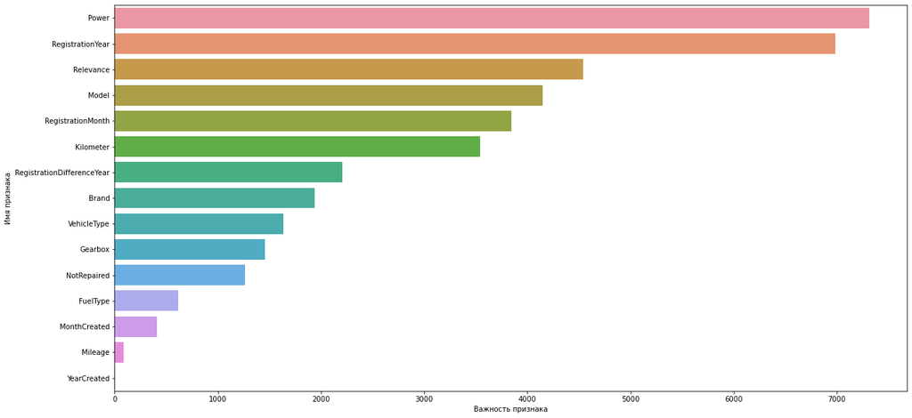

```python
feat_imp = pd.DataFrame({'FeatureName' : features_lgbm_test.columns, 'FeatureImportance' : model.feature_importances_})
feat_imp.sort_values('FeatureImportance', ascending=False, inplace=True)
fig, ax = plt.subplots(figsize = (20, 10))
ax = sns.barplot(ax = ax, data = feat_imp, y = 'FeatureName', x = 'FeatureImportance');
plt.xlabel('Важность признака')
plt.ylabel('Имя признака');
```

В отличие от CatBoost, LightGBM смог повысить точность предсказания, используя сгенерированные нами признаки. Однако признак YearCreated не увеличивает точность предсказания модели. Попробуем посмотреть на качество предсказаний, если обучить модель без неинформативного признака.

```python
model = LGBMRegressor(n_estimators=800, colsample_bytree=0.7, subsample=0.7, learning_rate=0.11, num_leaves=51)
start = time.time()
model.fit(features_lgbm_train[list(feat_imp['FeatureName'])[:-1]], target_lgbm_train, eval_metric='RMSE',
          categorical_feature = cat_features)
end = time.time()
learn_time = end - start
start = time.time()
predictions = model.predict(features_lgbm_test[list(feat_imp['FeatureName'])[:-1]])
end = time.time()
predict_time = end - start
print('RMSE на отложенной выборке: {:.6f} евро, время обучения модели: {:.2f} секунд, время построение прогноза: {:.2f}\
 секунд, стандартная ошибка отложенного таргета: {:.6f} евро'.\
      format(mse(target_lgbm_test, predictions, squared=False), learn_time, predict_time, target_lgbm_test.std()))
```

```
RMSE на отложенной выборке: 1633.116776 евро, время обучения модели: 5.22 секунд, время построение прогноза: 0.77 секунд, стандартная ошибка отложенного таргета: 4529.917661 евро
```

Видим, что точность предсказания выросла на 2 евро. Попробуем убрать следующий наименее информативный признак - Mileage. Этот признак является категориальным, поэтому при передаче модели списка категориальных признаков его нужно убрать из списка. Сделаем это с помощью слайзов.

```python
model = LGBMRegressor(n_estimators=800, colsample_bytree=0.7, subsample=0.7, learning_rate=0.11, num_leaves=51)
start = time.time()
model.fit(features_lgbm_train[list(feat_imp['FeatureName'])[:-2]], target_lgbm_train, eval_metric='RMSE',
          categorical_feature = cat_features[:-1])
end = time.time()
learn_time = end - start
start = time.time()
predictions = model.predict(features_lgbm_test[list(feat_imp['FeatureName'])[:-2]])
end = time.time()
predict_time = end - start
print('RMSE на отложенной выборке: {:.6f} евро, время обучения модели: {:.2f} секунд, время построение прогноза: {:.2f}\
 секунд, стандартная ошибка отложенного таргета: {:.6f} евро'.\
      format(mse(target_lgbm_test, predictions, squared=False), learn_time, predict_time, target_lgbm_test.std()))
```

```
RMSE на отложенной выборке: 1634.290847 евро, время обучения модели: 5.35 секунд, время построение прогноза: 0.76 секунд, стандартная ошибка отложенного таргета: 4529.917661 евро
```

Видим, что точность перестаёт расти: относительно модели, обученной без признака YearCreated, модель без признаков YearCreated и Mileage предсказывает цену на автомобили хуже, чем модель, обученная только без признака YearCreated.

Но ведь CatBoost работает прекрасно из коробки без тюнинга. Посмотрим, насколько эффективно будет работать из коробки LightGBM.

При этом удалим признак YearCreated, так как без него модель предсказывает цену чуть точнее.

```python
model = LGBMRegressor()
start = time.time()
model.fit(features_lgbm_train[list(feat_imp['FeatureName'])[:-1]], target_lgbm_train,
          eval_metric='RMSE', categorical_feature = cat_features)
end = time.time()
learn_time = end - start
start = time.time()
predictions = model.predict(features_lgbm_test[list(feat_imp['FeatureName'])[:-1]])
end = time.time()
predict_time = end - start
print('RMSE на отложенной выборке: {:.6f} евро, время обучения модели: {:.2f} секунд, время построение прогноза: {:.2f}\
 секунд, стандартная ошибка отложенного таргета: {:.6f} евро'.\
      format(mse(target_lgbm_test, predictions, squared=False), learn_time, predict_time, target_lgbm_test.std()))
```

```
RMSE на отложенной выборке: 1733.868926 евро, время обучения модели: 1.20 секунд, время построение прогноза: 0.18 секунд, стандартная ошибка отложенного таргета: 4529.917661 евро
```

CatBoost из коробки обеспечил RMSE на уровне 1704.01 евро евро на отложенной выборке, в то время как LightGBM обеспечивает RMSE на уровне 1733.87 евро. Разница небольшая, однако очевидно, что затюненный LightGBM работает куда эффективнее CatBoost из коробки.

# Вывод по этапу 3.

На данном этапе были построены модели, основанные на алгоритмах CatBoost и LightGBM, при этом CatBoost был использован из коробки, а LightGBM мы затюнили.

# Итоговый вывод по проекту.

Сервис по продаже автомобилей с пробегом «Не бит, не крашен» разрабатывает приложение для привлечения новых клиентов. В нём можно быстро узнать рыночную стоимость своего автомобиля. В вашем распоряжении исторические данные: технические характеристики, комплектации и цены автомобилей. Вам нужно построить модель для определения стоимости.

Заказчику важны:

- качество предсказания;
- скорость предсказания;
- время обучения.

**Целью проекта** являлось построение модели градиентного бустинга для предсказания стоимости подержанного автомобиля, основываясь на различных параметрах, характиризующих различные свойства описываемого автомобиля.

**Целевой метрикой** проекта являлась RMSE.

По условиям проекта необходимо было самостоятельно освоить библиотеку LightGBM, в частности - её модуль LGBMRegressor, так как задача проекта является задачей регрессии, однако в рамках эксперимента мы сравнили работу этой модели с моделью градиентного бустинга CatBoost.

Работа над проектом осуществлялась в следующем порядке:

1. Импорт библиотек, считывание набора данных и его первиный анализ.
2. Предобработка данных.
3. Построение моделей, выбор оптимальной модели.

Отметим некоторые выводы о проведённой работе.

# Вывод по этапу 1.

На данном этапе были импортированы необходимые библиотеки, а также считан и проанализирован первичный набор данных.

По итогу первичного анализа набора данных можно отметить следующие его особенности:

1. Набор данных содержит 16 признаков, в том числе признак Price, являющийся целевым.
2. Набор данных содержит 354 369 объектов.
3. В наборе данных содержатся пропуски:
- признак VehicleType - 37 490 пропусков;
- признак Gearbox - 19 833 пропуска;
- признак Model - 19 705 пропусков;
- признак FuelType - 32 895 пропусков;
- признак NotRepaired - 71 154 пропусков.

Пропуски могли быть обусловлены либо проблемами с хранилищем данных сервиса по продаже автомобилей, либо изначальным отсутствием этих сведений в объявлениях, так как платформа - агрегатор вторичных объявлений, где какие-то параметры могут быть не заполнены.

1. Набор данных содержит 4 дубликата: возможно, одно объявление было загружено несколько раз в связи с техническими неполадками сервиса при загрузке, когда пользователь видел сообщение о том, что объявление не было загружено, хотя на самом деле они загружались при каждой попытке.
2. Данные в наборе данных являются либо данными в формате int64, либо данными в формате object, хотя фактически у нас есть также поля и с датами. Чтобы с ними работать, их нужно будет перевести в формат datetime с помощью соответствующего метода Pandas.
3. Поле NumberOfPictures кажется аномальным и содержит только объекты с меткой 0. Потенциально этот признак не представляет ценности для моделирования, и его смело можно удалить из набора данных.

# Выводы по этапу 2.

На данном этапе мы осуществили предобработку данных по следующим направлениям:

1. Избавиться от дубликатов.
2. Сгенерировать новые признаки.
3. Избавиться от пропусков.

Мы успешно избавились от дубоикатов, на основе признаков даты и пробега сгенерировали новые, потенциально полезные признаки, а также избавились от пропусков, сведя их к новой категории nan.

Также мы удалили признаки с датой, на основе которых были сгенерированы новые признаки, а также избавились от аномального признака NumberOfPictures, единственным уникальным значением которого был 0.

# Вывод по этапу 3.

На данном этапе были построены модели, основанные на алгоритмах CatBoost и LightGBM, при этом CatBoost был использован из коробки, а LightGBM мы затюнили.

Сравнительный анализ результатов работы двух алгоритмов по критериям точности, скорости обучения и скорости предсказания представим в таблице.

```python
result = pd.DataFrame({'RMSE, евро' : [1634.29, 1704.01], 'Скорость обучения, сек.' : [5.35, 205.73],
                   'Скорость предсказания, сек.' : [0.76, 0.36]}, index = ['LightGBM', 'CatBoost'])
result
```

|  | RMSE, евро | Скорость обучения, сек. | Скорость предсказания, сек. |
| --- | --- | --- | --- |
| LightGBM | 1634.29 | 5.35 | 0.76 |
| CatBoost | 1704.01 | 205.73 | 0.36 |